# Midterm Part 2

Install packages if not already installed and load required libraries.

```r
# Install necessary packages if not already installed
if (!require("MASS")) install.packages("MASS")
if (!require("copula")) install.packages("copula")

# Load required libraries
library(MASS)
library(copula)
```

1. 1. Generate 1000, 10000, and 100000 pairs of uniform random variables U and V. Provide a brief summary of the sample statistics (mean and standard deviation) for each sample size.

```r
# Sample sizes
sample_sizes <- c(1000, 10000, 100000)

# Simulate uniform random variables
simulate_uniform_rvs <- function(n) {
  set.seed(123)  # For reproducibility
  U <- runif(n)
  V <- runif(n)
  return(list(U = U, V = V))
}

# Simulate for each sample size
uniform_samples <- lapply(sample_sizes, simulate_uniform_rvs)

# Print brief summary statistics for verification
summary_stats <- lapply(uniform_samples, function(sample) {
  U <- sample$U
  V <- sample$V
  return(data.frame(
    Sample_Size = length(U),
    Mean_U = mean(U), SD_U = sd(U),
    Mean_V = mean(V), SD_V = sd(V)
  ))
})

print(summary_stats)
```

```
[[1]]
  Sample_Size    Mean_U      SD_U    Mean_V      SD_V
1        1000 0.4972778 0.2874839 0.4982565 0.2857058

[[2]]
  Sample_Size    Mean_U      SD_U    Mean_V      SD_V
1       10000 0.4975494 0.2866937 0.4962693 0.2882863

[[3]]
  Sample_Size    Mean_U      SD_U    Mean_V      SD_V
1      100000 0.4992992 0.2884067 0.4999652 0.2888358
```

1(b)

```r
# Parameters for log-normal distribution
mean_X <- 50
var_X <- 25^2
mean_Y <- 50
var_Y <- 40^2

# Calculate parameters for log-normal distribution
mu_X <- log(mean_X^2 / sqrt(var_X + mean_X^2))
sigma_X <- sqrt(log(1 + var_X / mean_X^2))

mu_Y <- log(mean_Y^2 / sqrt(var_Y + mean_Y^2))
sigma_Y <- sqrt(log(1 + var_Y / mean_Y^2))

# Function to simulate log-normal RVs from previous uniform samples
simulate_lognormal_rvs <- function(U, V, mu_X, sigma_X, mu_Y, sigma_Y) {
  X <- qlnorm(U, mu_X, sigma_X)
  Y <- qlnorm(V, mu_Y, sigma_Y)

  return(list(X = X, Y = Y))
}

# Generate log-normal variables for each sample size
lognormal_samples <- lapply(uniform_samples, function(sample) {
  simulate_lognormal_rvs(sample$U, sample$V, mu_X, sigma_X, mu_Y, sigma_Y)
})

# Print brief summary statistics for verification
lognormal_summary_stats <- lapply(lognormal_samples, function(sample) {
  X <- sample$X
  Y <- sample$Y
  return(data.frame(
    Sample_Size = length(X),
    Mean_X = mean(X), SD_X = sd(X),
    Mean_Y = mean(Y), SD_Y = sd(Y)
  ))
})

print(lognormal_summary_stats)
```

```
[[1]]
  Sample_Size  Mean_X     SD_X   Mean_Y     SD_Y
1        1000 49.6635 24.44024 49.77084 40.30232

[[2]]
  Sample_Size Mean_X     SD_X   Mean_Y     SD_Y
1       10000 49.685 24.69159 49.40181 38.89668

[[3]]
  Sample_Size   Mean_X     SD_X   Mean_Y     SD_Y
1      100000 49.94805 24.94915 49.99129 40.12421
```

1(c)

```r
# Function to calculate empirical mean and standard deviation
calculate_statistics <- function(samples) {
  X <- samples$X
  Y <- samples$Y
  mean_X_empirical <- mean(X)
  sd_X_empirical <- sd(X)
  mean_Y_empirical <- mean(Y)
  sd_Y_empirical <- sd(Y)
  return(data.frame(
    Variable = c("X", "Y"),
    Mean_Empirical = c(mean_X_empirical, mean_Y_empirical),
    SD_Empirical = c(sd_X_empirical, sd_Y_empirical),
    Mean_Theoretical = c(mean_X, mean_Y),
    SD_Theoretical = c(sqrt(var_X), sqrt(var_Y))
  ))
}

# Calculate statistics for each sample size
statistics_results <- lapply(lognormal_samples, calculate_statistics)

# Print results in table format
statistics_results
```

| Variable | Mean_Empirical | SD_Empirical | Mean_Theoretical | SD_Theoretical |
| --- | --- | --- | --- | --- |
| X | 49.66350 | 24.44024 | 50 | 25 |
| Y | 49.77084 | 40.30232 | 50 | 40 |

| Variable | Mean_Empirical | SD_Empirical | Mean_Theoretical | SD_Theoretical |
| --- | --- | --- | --- | --- |
| X | 49.68500 | 24.69159 | 50 | 25 |
| Y | 49.40181 | 38.89668 | 50 | 40 |

| Variable | Mean_Empirical | SD_Empirical | Mean_Theoretical | SD_Theoretical |
| --- | --- | --- | --- | --- |
| X | 49.94805 | 24.94915 | 50 | 25 |
| Y | 49.99129 | 40.12421 | 50 | 40 |

```
NA
```

1(d) Additional Information Needed Covariance or Correlation between X and Y: Covariance (Cov(X,Y)): This measures the degree to which the returns of X and Y change together. It’s essential to determine the portfolio’s risk. Correlation (ρX,Y): This is a standardized measure of the relationship between X and Y, ranging from -1 to 1. It is often more interpretable than covariance.

Dependency Structure: If X and Y are not independent, knowing their joint distribution or copula is important. The copula captures the dependency structure between the variables, which affects the combined risk and return of the portfolio Z. Copula Parameters: For example, if using a Gaussian copula, we need the correlation matrix. For other copulas, we need the specific parameters that define the dependency structure.

```r
# Function to construct linear portfolio and calculate necessary information
construct_portfolio <- function(samples) {
  X <- samples$X
  Y <- samples$Y
  Z <- X + Y
  mean_Z <- mean(Z)
  sd_Z <- sd(Z)
  return(list(Z = Z, mean_Z = mean_Z, sd_Z = sd_Z))
}

# Construct portfolios for each sample size
portfolio_results <- lapply(lognormal_samples, construct_portfolio)

# Print results for verification
portfolio_results
```

[output not shown]

[output cut: 765 more lines]

2(a)

```r
# Function to calculate VaR
calculate_VaR <- function(samples, alpha) {
  return(quantile(samples, probs = alpha))
}

#define alpha
alpha <- 0.995

VaR_results <-lapply(lognormal_samples, function(samples) {
  X <- samples$X
  Y <- samples$Y

  VaR_X <- calculate_VaR(X, alpha)
  VaR_Y <- calculate_VaR(Y, alpha)

  return(list(VaR_X = VaR_X, VaR_Y = VaR_Y))
})

# Print VaR results
VaR_results_table <- data.frame(VaR_results)
VaR_results_table
```

|  | VaR_X | VaR_Y | VaR_X.1 | VaR_Y.1 | VaR_X.2 | VaR_Y.2 |
| --- | --- | --- | --- | --- | --- | --- |
| 99.5% | 142.576 | 235.1953 | 149.3758 | 220.126 | 150.6791 | 237.4704 |

2(b)

```r
# New function to simulate log-normal RVs from uniform samples using n, disregarding previous U and V
simulate_lognormal_rvs1 <- function(n, mu_X, sigma_X, mu_Y, sigma_Y) {
  U <- runif(n)
  V <- runif(n)
  X <- qlnorm(U, mu_X, sigma_X)
  Y <- qlnorm(V, mu_Y, sigma_Y)
  return(list(X = X, Y = Y))
}
# Function to perform VaR stability analysis
VaR_stability_analysis <- function(n, num_iterations, alpha, mu_X, sigma_X, mu_Y, sigma_Y) {
  VaR_X_values <- numeric(num_iterations)
  VaR_Y_values <- numeric(num_iterations)

  for (i in 1:num_iterations) {
    samples <- simulate_lognormal_rvs1(n, mu_X, sigma_X, mu_Y, sigma_Y)
    X <- samples$X
    Y <- samples$Y

    VaR_X_values[i] <- calculate_VaR(X, alpha)
    VaR_Y_values[i] <- calculate_VaR(Y, alpha)
  }

  std_dev_VaR_X <- sd(VaR_X_values)
  std_dev_VaR_Y <- sd(VaR_Y_values)

  return(list(std_dev_VaR_X = std_dev_VaR_X, std_dev_VaR_Y = std_dev_VaR_Y))
}

# Perform VaR stability analysis for each sample size
num_iterations <- 100

stability_results <- lapply(sample_sizes, function(n) {
  VaR_stability_analysis(n, num_iterations, alpha, mu_X, sigma_X, mu_Y, sigma_Y)
})

# Print stability results
stability_results
```

```
[[1]]
[[1]]$std_dev_VaR_X
[1] 11.02962

[[1]]$std_dev_VaR_Y
[1] 22.52905


[[2]]
[[2]]$std_dev_VaR_X
[1] 3.50575

[[2]]$std_dev_VaR_Y
[1] 8.5729


[[3]]
[[3]]$std_dev_VaR_X
[1] 0.9405216

[[3]]$std_dev_VaR_Y
[1] 2.83923
```

2(c)

```r
comparison_table <- data.frame(
  Sample_Size = sample_sizes,
  Std_Dev_VaR_X = sapply(stability_results, function(res) res$std_dev_VaR_X),
  Std_Dev_VaR_Y = sapply(stability_results, function(res) res$std_dev_VaR_Y)
)

# Print comparison table
print(comparison_table)
```

| Sample_Size | Std_Dev_VaR_X | Std_Dev_VaR_Y |
| --- | --- | --- |
| 1e+03 | 11.0296209 | 22.52905 |
| 1e+04 | 3.5057498 | 8.57290 |
| 1e+05 | 0.9405216 | 2.83923 |

3(a)

```r
if (!require("ggplot2")) install.packages("ggplot2")

library(ggplot2)
```

```r
# Define alpha for VaR calculation
alpha <- 0.995
theta <- 2
sample_sizes <- c(1000, 10000, 100000)

# Parameters for log-normal distribution
mean_X <- 50
var_X <- 25^2
mean_Y <- 50
var_Y <- 40^2

# Calculate parameters for log-normal distribution
mu_X <- log(mean_X^2 / sqrt(var_X + mean_X^2))
sigma_X <- sqrt(log(1 + var_X / mean_X^2))

mu_Y <- log(mean_Y^2 / sqrt(var_Y + mean_Y^2))
sigma_Y <- sqrt(log(1 + var_Y / mean_Y^2))

# Remind the same new Function to simulate log-normal RVs from uniform samples
simulate_lognormal_rvs1 <- function(n, mu_X, sigma_X, mu_Y, sigma_Y) {
  U <- runif(n)
  V <- runif(n)
  X <- qlnorm(U, mu_X, sigma_X)
  Y <- qlnorm(V, mu_Y, sigma_Y)
  return(list(X = X, Y = Y))
}

# Function to simulate Clayton survival copula
simulate_clayton_survival_copula <- function(n, theta) {
  # Define the Clayton copula
  clayton_copula <- claytonCopula(theta, dim = 2)
  # Simulate data from the Clayton copula
  uv <- rCopula(n, clayton_copula)
  # Transform to survival copula
  uv_survival <- cbind(1 - uv[, 1], 1 - uv[, 2])
  return(uv_survival)
}


# Function to calculate VaR and expected value
calculate_rho <- function(samples, alpha) {
  VaR <- quantile(samples, probs = alpha)
  mean_val <- mean(samples)
  rho <- VaR - mean_val
  return(list(VaR = VaR, mean = mean_val, rho = rho))
}

# Function to calculate diversification benefit
calculate_DB <- function(rho_Z, rho_X, rho_Y) {
  DB <- 1 - (rho_Z / (rho_X + rho_Y))
  return(DB)
}

# Function to calculate all rhos and DB for a given set of samples
calculate_all_rhos <- function(X, Y, alpha) {
  Z <- X + Y
  rho_X <- calculate_rho(X, alpha)$rho
  rho_Y <- calculate_rho(Y, alpha)$rho
  rho_Z <- calculate_rho(Z, alpha)$rho
  DB <- calculate_DB(rho_Z, rho_X, rho_Y)
  return(list(rho_X = rho_X, rho_Y = rho_Y, rho_Z = rho_Z, DB = DB))
}

# Function to calculate correlation metrics
calculate_correlations <- function(X, Y) {
  pearson_corr <- cor(X, Y)
  spearman_corr <- cor(X, Y, method = "spearman")
  kendall_corr <- cor(X, Y, method = "kendall")
  return(list(pearson = pearson_corr, spearman = spearman_corr, kendall = kendall_corr))
}

# Function to plot rank scatter plot
plot_rank_scatter <- function(X, Y, title) {
  df <- data.frame(X = rank(X), Y = rank(Y))
  p <- ggplot(df, aes(x = X, y = Y)) +
    geom_point(alpha = 0.5) +
    labs(title = title, x = "Rank of X", y = "Rank of Y") +
    theme_minimal()
  print(p)
}
```

```
Processing sample size: 1000
Processing sample size: 10000
Processing sample size: 1e+05
```

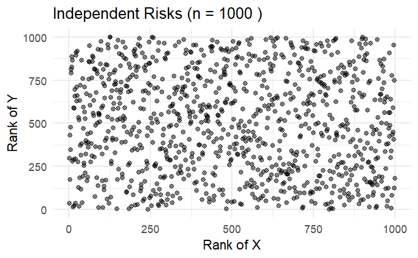

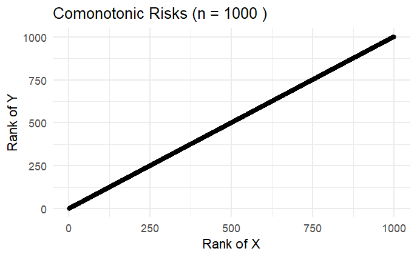

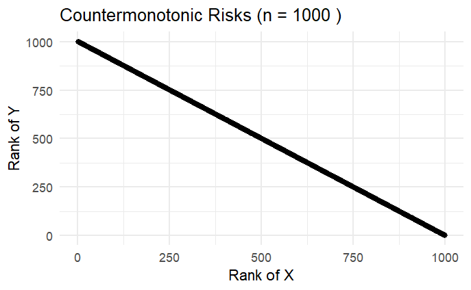

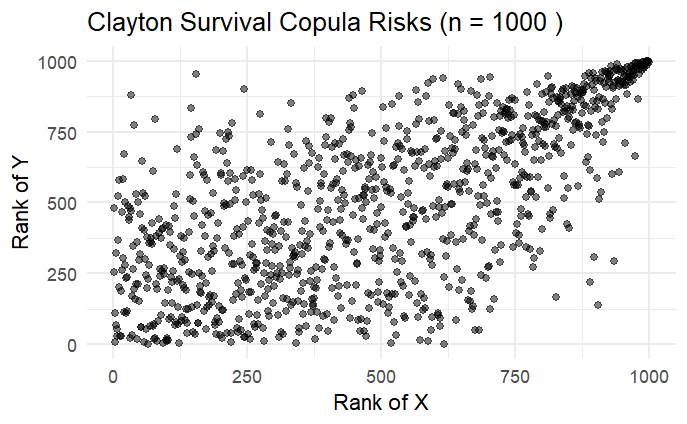

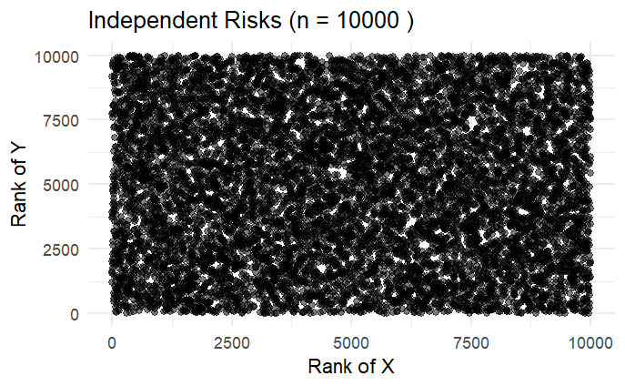

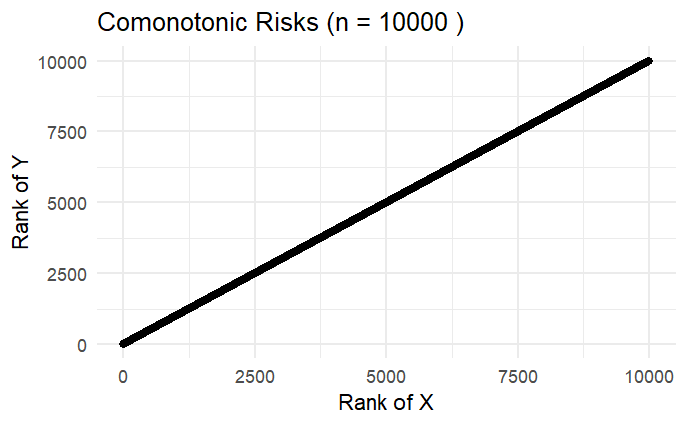

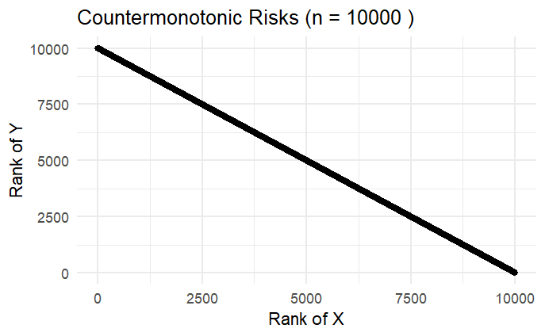

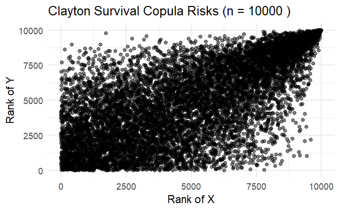

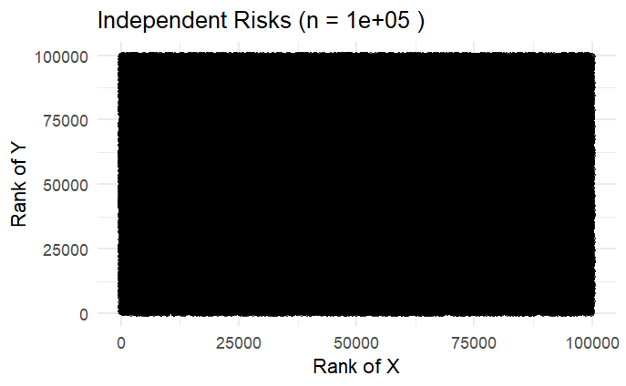

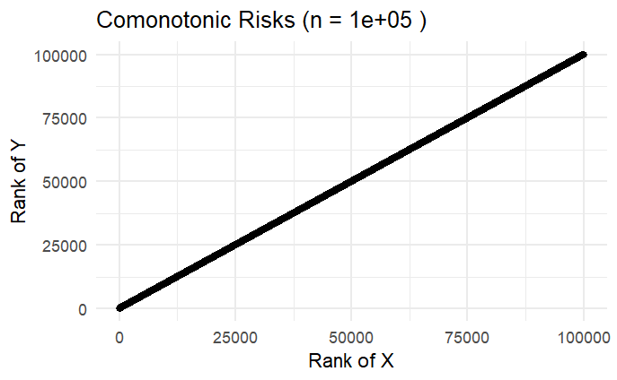

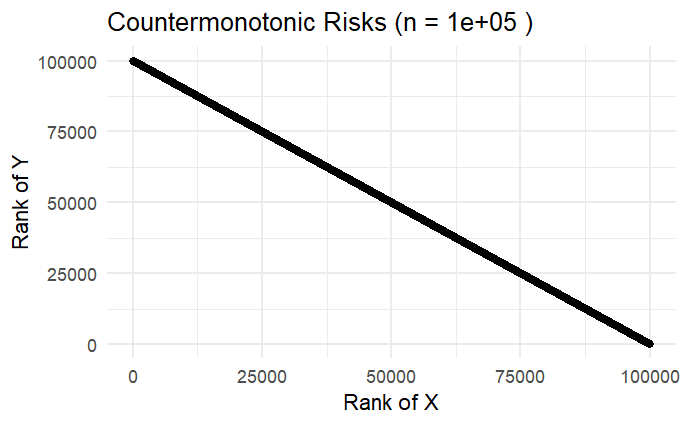

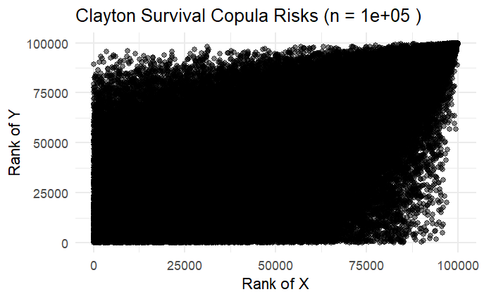

```r
# Iterate over sample sizes
results <- lapply(sample_sizes, function(n) {
  cat("Processing sample size:", n, "\n")

  # Simulate original log-normal samples
  lognormal_samples <- simulate_lognormal_rvs1(n, mu_X, sigma_X, mu_Y, sigma_Y)
  X_independent <- lognormal_samples$X
  Y_independent <- lognormal_samples$Y

  # (i) Independent Risks
  independent_results <- calculate_all_rhos(X_independent, Y_independent, alpha)
  independent_correlations <- calculate_correlations(X_independent, Y_independent)
  plot_rank_scatter(X_independent, Y_independent, paste("Independent Risks (n =", n, ")"))

  # (ii) Comonotonic Risks
  X_comonotonic <- sort(X_independent)
  Y_comonotonic <- sort(Y_independent)
  comonotonic_results <- calculate_all_rhos(X_comonotonic, Y_comonotonic, alpha)
  comonotonic_correlations <- calculate_correlations(X_comonotonic, Y_comonotonic)
  plot_rank_scatter(X_comonotonic, Y_comonotonic, paste("Comonotonic Risks (n =", n, ")"))

  # (iii) Countermonotonic Risks
  X_countermonotonic <- sort(X_independent)
  Y_countermonotonic <- sort(Y_independent, decreasing = TRUE)
  countermonotonic_results <- calculate_all_rhos(X_countermonotonic, Y_countermonotonic, alpha)
  countermonotonic_correlations <- calculate_correlations(X_countermonotonic, Y_countermonotonic)
  plot_rank_scatter(X_countermonotonic, Y_countermonotonic, paste("Countermonotonic Risks (n =", n, ")"))

  # (iv) Dependent Risks via Clayton Survival Copula
  uv_clayton <- simulate_clayton_survival_copula(n, theta)
  U_clayton <- uv_clayton[, 1]
  V_clayton <- uv_clayton[, 2]
  X_clayton <- qlnorm(U_clayton, mu_X, sigma_X)
  Y_clayton <- qlnorm(V_clayton, mu_Y, sigma_Y)
  clayton_results <- calculate_all_rhos(X_clayton, Y_clayton, alpha)
  clayton_correlations <- calculate_correlations(X_clayton, Y_clayton)
  plot_rank_scatter(X_clayton, Y_clayton, paste("Clayton Survival Copula Risks (n =", n, ")"))

  # Collect results
  list(
    sample_size = n,
    independent = list(results = independent_results, correlations = independent_correlations),
    comonotonic = list(results = comonotonic_results, correlations = comonotonic_correlations),
    countermonotonic = list(results = countermonotonic_results, correlations = countermonotonic_correlations),
    clayton = list(results = clayton_results, correlations = clayton_correlations)
  )
})
```

```r
# Print the results
print(results)
```

```
[[1]]
[[1]]$sample_size
[1] 1000

[[1]]$independent
[[1]]$independent$results
[[1]]$independent$results$rho_X
   99.5%
88.36411

[[1]]$independent$results$rho_Y
   99.5%
172.6012

[[1]]$independent$results$rho_Z
   99.5%
176.7771

[[1]]$independent$results$DB
    99.5%
0.3226033


[[1]]$independent$correlations
[[1]]$independent$correlations$pearson
[1] -0.03490946

[[1]]$independent$correlations$spearman
[1] -0.06132999

[[1]]$independent$correlations$kendall
[1] -0.04014014



[[1]]$comonotonic
[[1]]$comonotonic$results
[[1]]$comonotonic$results$rho_X
   99.5%
88.36411
```

[output cut: 328 more lines]

```

[[3]]$clayton$results$DB
     99.5%
0.01720234


[[3]]$clayton$correlations
[[3]]$clayton$correlations$pearson
[1] 0.8140058

[[3]]$clayton$correlations$spearman
[1] 0.6791646

[[3]]$clayton$correlations$kendall
[1] 0.4976098
```

```r
# Format results into a comparison table
comparison_table <- do.call(rbind, lapply(results, function(res) {
  data.frame(
    Sample_Size = res$sample_size,
    Independent_DB = res$independent$results$DB,
    Comonotonic_DB = res$comonotonic$results$DB,
    Countermonotonic_DB = res$countermonotonic$results$DB,
    Clayton_DB = res$clayton$results$DB
  )
}))

print(comparison_table)
```

|  | Sample_Size | Independent_DB | Comonotonic_DB | Countermonotonic_DB | Clayton_DB |
| --- | --- | --- | --- | --- | --- |
| 99.5% | 1e+03 | 0.3226033 | 0.000000e+00 | 0.4762255 | 0.03281886 |
| 99.5%1 | 1e+04 | 0.3032362 | -2.220446e-16 | 0.4567464 | 0.01060401 |
| 99.5%2 | 1e+05 | 0.3106495 | 2.220446e-16 | 0.4727127 | 0.01720234 |

```r
NA
NA
```

```r
if (!require("dplyr")) install.packages("dplyr")
if (!require("knitr")) install.packages("knitr")
if (!require("kableExtra")) install.packages("kableExtra")

library(dplyr)
library(knitr)
library(kableExtra)
```

```r
# Format results into a comparison table for correlations
correlation_table <- do.call(rbind, lapply(results, function(res) {
  data.frame(
    Sample_Size = res$sample_size,
    Type = c("Independent", "Comonotonic", "Countermonotonic", "Clayton"),
    Pearson = c(res$independent$correlations$pearson, res$comonotonic$correlations$pearson,
                res$countermonotonic$correlations$pearson, res$clayton$correlations$pearson),
    Spearman = c(res$independent$correlations$spearman, res$comonotonic$correlations$spearman,
                 res$countermonotonic$correlations$spearman, res$clayton$correlations$spearman),
    Kendall = c(res$independent$correlations$kendall, res$comonotonic$correlations$kendall,
                res$countermonotonic$correlations$kendall, res$clayton$correlations$kendall)
  )
}))

# Print the correlation table
correlation_table %>%
  kable("html") %>%
  kable_styling(bootstrap_options = c("striped", "hover", "condensed"), full_width = F)
```

| Sample_Size | Type | Pearson | Spearman | Kendall |
| --- | --- | --- | --- | --- |
| 1e+03 | Independent | -0.0349095 | -0.0613300 | -0.0401401 |
| 1e+03 | Comonotonic | 0.9867495 | 1.0000000 | 1.0000000 |
| 1e+03 | Countermonotonic | -0.7288580 | -1.0000000 | -1.0000000 |
| 1e+03 | Clayton | 0.8036388 | 0.6627331 | 0.4840040 |
| 1e+04 | Independent | -0.0114796 | -0.0107410 | -0.0072129 |
| 1e+04 | Comonotonic | 0.9870957 | 1.0000000 | 1.0000000 |
| 1e+04 | Countermonotonic | -0.7098400 | -1.0000000 | -1.0000000 |
| 1e+04 | Clayton | 0.8159936 | 0.6865748 | 0.5040550 |
| 1e+05 | Independent | -0.0039194 | -0.0034054 | -0.0022718 |
| 1e+05 | Comonotonic | 0.9848509 | 1.0000000 | 1.0000000 |
| 1e+05 | Countermonotonic | -0.7099568 | -1.0000000 | -1.0000000 |
| 1e+05 | Clayton | 0.8140058 | 0.6791646 | 0.4976098 |